# Project 1: Wrangling, Exploration, Visualization

SDS322E

## Data Wrangling, Exploration, Visualization

### Debbie Gonzalez dg37725

#### Introduction

I chose to use my Spotify data from the last two months as well as the weather data for the same time period. My Spotify data, StreamingHistory, contains the variables Date, Time, artistName, trackName, and msPlayed. My weather data, Weather, contains the variables Date, Name, Max Temp, Min Temp, Temp, Wind Chill, Conditions, and other weather variables. I acquired my Spotify data straight from Spotify, and I acquired my weather data from www.visualcrossing.com. This data is interesting to me because I wanted to see if I preferred to listen to music on certain weather conditions. I also wanted to see how Spotify does their Spotify Wrapped they do every year, and I was able to do it myself! I expect to see that I listen to Taylor Swift the most since I am a big fan, and I think I will listen to music most on cloudy days.

```r
# read your datasets in here, e.g., with read_csv()
library(tidyverse)
StreamingHistory <- read_csv("~/project1/StreamingHistory.csv")
Weather <- read_csv("~/project1/Weather.csv")
```

#### Tidying: Reshaping

If your datasets are tidy already, demonstrate that you can reshape data with pivot wider/longer here (e.g., untidy and then retidy). Alternatively, it may be easier to wait until the wrangling section so you can reshape your summary statistics. Note here if you are going to do this.

```r
# Here I am making sure both datasets have a common variable.
# They both share a date variable, but I had to rename and
# reformat it as shown below.
StreamingHistory <- StreamingHistory %>% separate(endTime, sep = " ",
    c("Date", "Time"))
Weather <- Weather %>% rename(Datee = "Date time")

Weather$Date <- strptime(as.character(Weather$Datee), "%m/%d/%Y")
Weather$Date <- format(Weather$Date, "%Y-%m-%d")
Weather <- Weather %>% select(-Datee)

# Here I use pivot wider and pivot longer to untidy then
# retidy my data.
Weather <- Weather %>% pivot_wider(names_from = Name, values_from = Date)

Weather <- Weather %>% pivot_longer(16, names_to = "Name", values_to = "Date")
```

#### Joining/Merging

```r
data <- left_join(StreamingHistory, Weather)

nrow(data)
```

```
## [1] 3272
```

```r
nrow(StreamingHistory)
```

```
## [1] 3272
```

```r
nrow(Weather)
```

```
## [1] 66
```

```r
ncol(data)
```

```
## [1] 21
```

```r
ncol(StreamingHistory)
```

```
## [1] 5
```

```r
ncol(Weather)
```

```
## [1] 17
```

```r
length(unique(StreamingHistory$Date))
```

```
## [1] 55
```

```r
length(unique(Weather$Date))
```

```
## [1] 66
```

```r
length(which(unique(StreamingHistory$Date) %in% unique(Weather$Date)))
```

```
## [1] 55
```

```r
length(which(unique(Weather$Date) %in% unique(StreamingHistory$Date)))
```

```
## [1] 55
```

```r
sum(unique(StreamingHistory$Date) %in% unique(Weather$Date))
```

```
## [1] 55
```

#### Wrangling

```r
# Here I use 4 dplyr functions (select, group by, arrange,
# and filter)
data %>% select(Date, artistName, Temperature) %>% group_by(artistName) %>%
    arrange(desc(Temperature)) %>% filter(Temperature < "80")
```

```
## # A tibble: 2,039 × 3
## # Groups:   artistName [537]
##    Date       artistName   Temperature
##    <chr>      <chr>              <dbl>
##  1 2021-09-30 Taylor Swift        79.8
##  2 2021-09-30 Taylor Swift        79.8
##  3 2021-09-30 J. Cole             79.8
##  4 2021-09-30 Taylor Swift        79.8
##  5 2021-09-30 Cuva                79.8
##  6 2021-09-30 Khalid              79.8
##  7 2021-09-30 Avenue Beat         79.8
##  8 2021-09-30 Saweetie            79.8
##  9 2021-09-30 Drake               79.8
## 10 2021-09-13 Saweetie            79.7
## # … with 2,029 more rows
```

```r
data %>% group_by(artistName) %>% summarize(trackName) %>% count() %>%
    arrange(desc(n))
```

```
## # A tibble: 713 × 2
## # Groups:   artistName [713]
##    artistName          n
##    <chr>           <int>
##  1 Taylor Swift      454
##  2 Kanye West        182
##  3 LANY              100
##  4 Olivia Rodrigo     97
##  5 The Band CAMINO    80
##  6 Saweetie           42
##  7 Valley             38
##  8 Coldplay           36
##  9 Miley Cyrus        36
## 10 Blake Rose         31
## # … with 703 more rows
```

```r
data %>% group_by(trackName, artistName) %>% count(trackName) %>%
    filter(artistName == "Taylor Swift") %>% arrange(desc(n))
```

```
## # A tibble: 134 × 3
## # Groups:   trackName, artistName [134]
##    trackName                         artistName       n
##    <chr>                             <chr>        <int>
##  1 Wildest Dreams (Taylor's Version) Taylor Swift    39
##  2 long story short                  Taylor Swift    23
##  3 Look What You Made Me Do          Taylor Swift    19
##  4 tolerate it                       Taylor Swift    18
##  5 ...Ready For It?                  Taylor Swift    13
##  6 22                                Taylor Swift    11
##  7 Call It What You Want             Taylor Swift    10
##  8 So It Goes...                     Taylor Swift     9
##  9 ‘tis the damn season              Taylor Swift     8
## 10 All Too Well                      Taylor Swift     8
## # … with 124 more rows
```

```r
data %>% group_by(artistName, Temperature, Date) %>% count(artistName) %>%
    arrange(desc(n))
```

```
## # A tibble: 1,813 × 4
## # Groups:   artistName, Temperature, Date [1,813]
##    artistName     Temperature Date           n
##    <chr>                <dbl> <chr>      <int>
##  1 Kanye West            82.8 2021-08-29    88
##  2 Taylor Swift          78   2021-10-26    68
##  3 Kanye West            84.2 2021-08-30    67
##  4 Taylor Swift          80.7 2021-10-13    43
##  5 Taylor Swift          70.4 2021-09-23    40
##  6 Taylor Swift          77.6 2021-10-04    36
##  7 Olivia Rodrigo        74.5 2021-09-25    35
##  8 Taylor Swift          61.2 2021-10-17    34
##  9 Taylor Swift          63.2 2021-10-18    27
## 10 Coldplay              75.4 2021-09-22    26
## # … with 1,803 more rows
```

```r
# Here I use 2 variables from my data set to create a new
# dataset using mutate
data %>% mutate(TempDiff = `Maximum Temperature` - `Minimum Temperature`)
```

```
## # A tibble: 3,272 × 22
##    Date   Time  artistName trackName  msPlayed `Maximum Temper… `Minimum Temper…
##    <chr>  <chr> <chr>      <chr>         <dbl>            <dbl>            <dbl>
##  1 2021-… 17:1… The Kid L… STAY (wit…   141805             95.6             73.8
##  2 2021-… 17:1… Sia        Genius (f…   213706             95.6             73.8
##  3 2021-… 17:2… 6LACK      One Way (…   241546             95.6             73.8
##  4 2021-… 17:2… Rihanna    Needed Me    191600             95.6             73.8
##  5 2021-… 17:2… Taylor Sw… Back To D…      938             95.6             73.8
##  6 2021-… 17:2… Julia Mic… 17           179547             95.6             73.8
##  7 2021-… 17:3… Jesse & J… Espacio s…   129194             95.6             73.8
##  8 2021-… 17:3… Noah Kahan False Con…   143829             95.6             73.8
##  9 2021-… 17:3… Valley     You          147605             95.6             73.8
## 10 2021-… 17:3… RL Grime   UCLA           8362             95.6             73.8
## # … with 3,262 more rows, and 15 more variables: Temperature <dbl>,
## #   Wind Chill <lgl>, Heat Index <dbl>, Precipitation <dbl>, Snow <dbl>,
## #   Snow Depth <dbl>, Wind Speed <dbl>, Wind Direction <dbl>, Wind Gust <dbl>,
## #   Visibility <dbl>, Cloud Cover <dbl>, Relative Humidity <dbl>,
## #   Conditions <chr>, Name <chr>, TempDiff <dbl>
```

```r
# Here I use str_replace_all
data$Time %>% str_replace_all(":00", "nice")
```

[output not shown]

```r
# Here I use summarize
data %>% summarize(Temperature, Conditions)
```

```
## # A tibble: 3,272 × 2
##    Temperature Conditions
##          <dbl> <chr>
##  1        84.4 Partially cloudy
##  2        84.4 Partially cloudy
##  3        84.4 Partially cloudy
##  4        84.4 Partially cloudy
##  5        84.4 Partially cloudy
##  6        84.4 Partially cloudy
##  7        84.4 Partially cloudy
##  8        84.4 Partially cloudy
##  9        84.4 Partially cloudy
## 10        84.4 Partially cloudy
## # … with 3,262 more rows
```

```r
# Summary statistics of numeric variables
data %>% summarize(quantilemsPlayed = quantile(msPlayed))
```

```
## # A tibble: 5 × 1
##   quantilemsPlayed
##              <dbl>
## 1               0
## 2            3366
## 3           93494
## 4          194655.
## 5         3062408
```

```r
data %>% summarize(meanMaxTemp = mean(`Maximum Temperature`))
```

```
## # A tibble: 1 × 1
##   meanMaxTemp
##         <dbl>
## 1        88.6
```

```r
data %>% summarize(varMinTemp = var(`Minimum Temperature`))
```

```
## # A tibble: 1 × 1
##   varMinTemp
##        <dbl>
## 1       57.4
```

```r
data %>% summarize(sdTemp = sd(Temperature))
```

```
## # A tibble: 1 × 1
##   sdTemp
##    <dbl>
## 1   6.31
```

```r
data %>% summarize(corWind = cor(`Wind Speed`, `Wind Direction`))
```

```
## # A tibble: 1 × 1
##   corWind
##     <dbl>
## 1   0.307
```

```r
data %>% summarize(maxRelativeHumidity = max(`Relative Humidity`))
```

```
## # A tibble: 1 × 1
##   maxRelativeHumidity
##                 <dbl>
## 1                87.6
```

```r
data %>% summarize(n_distinct(`Heat Index`))
```

```
## # A tibble: 1 × 1
##   `n_distinct(\`Heat Index\`)`
##                          <int>
## 1                           47
```

```r
data %>% summarize(Visibility, n())
```

```
## # A tibble: 3,272 × 2
##    Visibility `n()`
##         <dbl> <int>
##  1        9.9  3272
##  2        9.9  3272
##  3        9.9  3272
##  4        9.9  3272
##  5        9.9  3272
##  6        9.9  3272
##  7        9.9  3272
##  8        9.9  3272
##  9        9.9  3272
## 10        9.9  3272
## # … with 3,262 more rows
```

```r
# Summary statistics of categorical variables
data %>% count(Date)
```

```
## # A tibble: 55 × 2
##    Date           n
##    <chr>      <int>
##  1 2021-08-22    47
##  2 2021-08-23    85
##  3 2021-08-24     9
##  4 2021-08-25    21
##  5 2021-08-26    24
##  6 2021-08-27    54
##  7 2021-08-28     6
##  8 2021-08-29   112
##  9 2021-08-30   177
## 10 2021-09-01     8
## # … with 45 more rows
```

```r
data %>% count(Time)
```

```
## # A tibble: 1,010 × 2
##    Time         n
##    <chr>    <int>
##  1 00:00:00     5
##  2 00:01:00     3
##  3 00:02:00     6
##  4 00:03:00     5
##  5 00:05:00     5
##  6 00:06:00     2
##  7 00:07:00     1
##  8 00:08:00     9
##  9 00:09:00     9
## 10 00:10:00     8
## # … with 1,000 more rows
```

```r
data %>% count(artistName)
```

```
## # A tibble: 713 × 2
##    artistName                 n
##    <chr>                  <int>
##  1 .irg                       1
##  2 100 gecs                   1
##  3 21 Savage                 12
##  4 5 Seconds of Summer        5
##  5 6LACK                      3
##  6 88GLAM                     4
##  7 88rising                   1
##  8 A Boogie Wit da Hoodie     1
##  9 A Great Big World          1
## 10 A N X                      1
## # … with 703 more rows
```

```r
data %>% count(trackName)
```

```
## # A tibble: 1,405 × 2
##    trackName                                           n
##    <chr>                                           <int>
##  1 _S W E E T .S O U |                                 1
##  2 ¡Corre!                                             1
##  3 ...Ready For It?                                   13
##  4 ‘tis the damn season                                8
##  5 ’til i don't                                        1
##  6 #47 Human-centered Design in Data Science           1
##  7 001 TMD How to Understand the Language of Math      1
##  8 003 TMD What are Negative Numbers and Integers?     1
##  9 1 Last Cigarette                                   10
## 10 1 step forward, 3 steps back                        7
## # … with 1,395 more rows
```

```r
data %>% count(Name)
```

```
## # A tibble: 1 × 2
##   Name                          n
##   <chr>                     <int>
## 1 Austin, TX, United States  3272
```

```r
data %>% count(Conditions)
```

```
## # A tibble: 5 × 2
##   Conditions                 n
##   <chr>                  <int>
## 1 Clear                   1711
## 2 Overcast                  87
## 3 Partially cloudy         916
## 4 Rain, Overcast           343
## 5 Rain, Partially cloudy   215
```

```r
# Number of missing values (NAs) for each variable
colSums(is.na(data))
```

```
##                Date                Time          artistName           trackName
##                   0                   0                   0                   0
##            msPlayed Maximum Temperature Minimum Temperature         Temperature
##                   0                   0                   0                   0
##          Wind Chill          Heat Index       Precipitation                Snow
##                3272                 439                   0                   0
##          Snow Depth          Wind Speed      Wind Direction           Wind Gust
##                   0                   0                   0                 933
##          Visibility         Cloud Cover   Relative Humidity          Conditions
##                   0                   0                   0                   0
##                Name
##                   0
```

I was also surprised by the breakdown of the number of times I listened to Taylor’s songs. I listened to Wildest Dreams (Taylor’s Version) 39 times, long story short 23 times, and Look What You Made Me Do 19 times. I was also interested to see that I didn’t have a preference for temperature. I mostly listen to Kanye West, Taylor Swift, and Olivia Rodrigo repeatedly in one day.

#### Visualizing

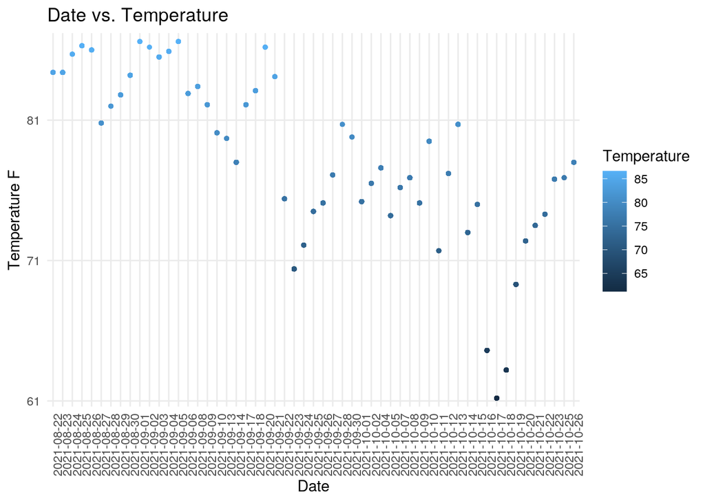

```r
data %>% ggplot(aes(Date, Temperature, color = Temperature)) +
    geom_point(size = 1) + ggtitle("Date vs. Temperature") +
    theme_minimal() + theme(axis.text.x = element_text(angle = 90)) +
    scale_y_discrete(name = "Temperature F", limits = c(61, 71,
        81))
```

This is a graph of Date as related to Temperature. We notice that the temperature gradually decreases as the date moves closer to the winter months.

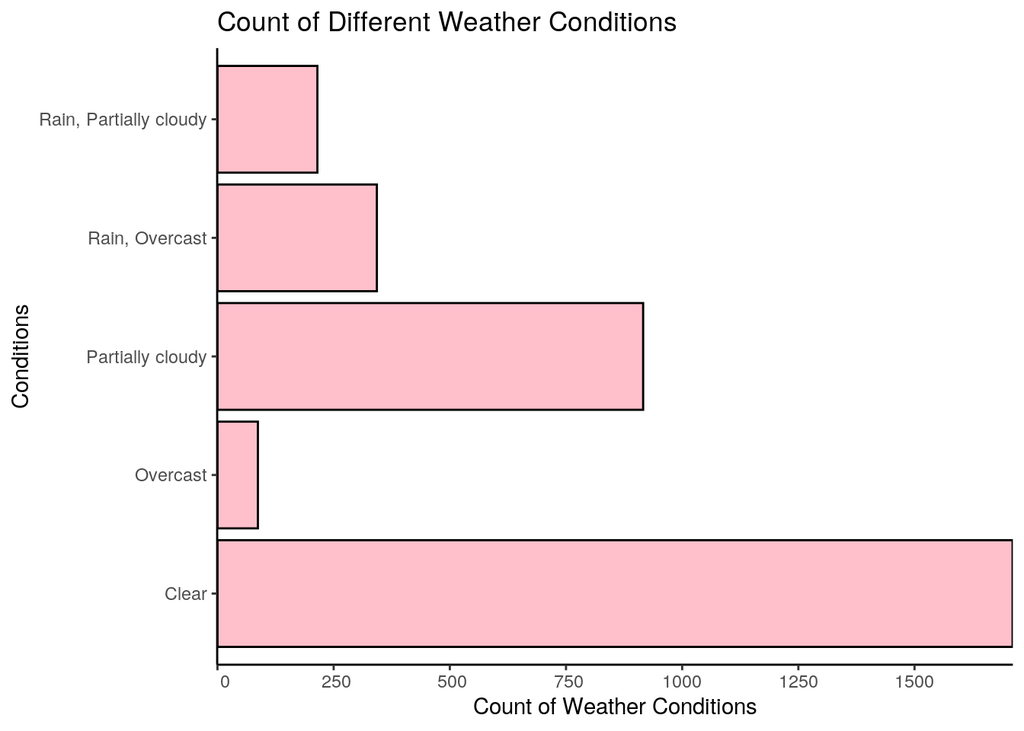

```r
data %>% ggplot(aes(Conditions)) + geom_bar(color = "black",
    fill = "pink") + ggtitle("Count of Different Weather Conditions") +
    theme_classic() + coord_flip() + scale_y_discrete(name = "Count of Weather Conditions",
    limits = c(0, 250, 500, 750, 1000, 1250, 1500))
```

This graph returns the frequency of conditions for every song I listened to. Here I found that I listened to music most when weather conditions were classified as ‘clear,’ and I listened to music least when the weather conditions were classified as ‘cloudy.’

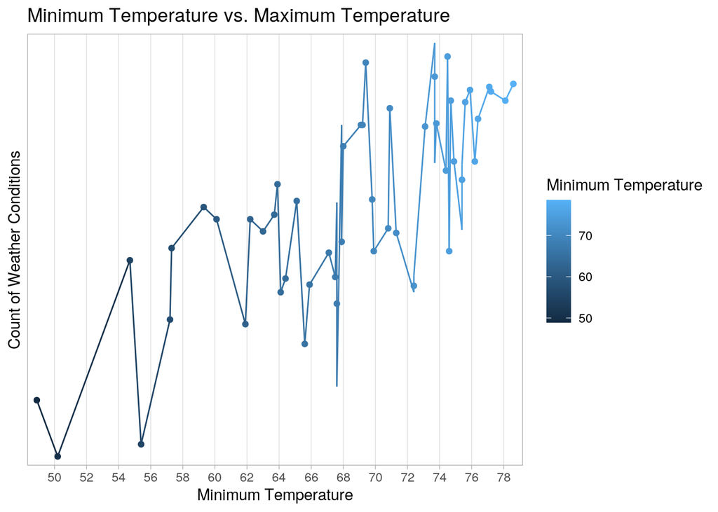

```r
data %>% ggplot(aes(`Minimum Temperature`, `Maximum Temperature`,
    color = `Minimum Temperature`)) + geom_point(stat = "summary") +
    geom_line() + scale_x_discrete(limits = c(50, 52, 54, 56,
    58, 60, 62, 64, 66, 68, 70, 72, 74, 76, 78)) + ggtitle("Minimum Temperature vs. Maximum Temperature") +
    theme_light() + scale_y_discrete("Count of Weather Conditions")
```

This is a graph of minimum temperature vs. maximum temperature. Here we generally see that the higher the minimum temperature, the higher the maximum temperature. Same for the lower the minimum temperature, the lower the maximum temperature. I also added more tick marks here than the default provided on the x axis. I also used stat = summary here.

#### Concluding Remarks

I’ve had fun applying what I’ve learned in class to this project. I am excited to learn more throughout the rest of the semester. While I did find that I listned to Taylor Swift the most, I was surprised to find that I listen to music on cloudy days the least. Overall, I’m so happy I can do my own Spotify Wrapped and got to see my listening trends for myself.